# Bayesian analysis of Adult Census data

Bayesian Modelling

Fabrizio Niro 5106988

18/07/2022

# Introduction

The dataset object of this analysis is the “Adult Census” dataset. It is also known as “Adult” dataset. It has been donated to UCI from Ronny Kohavi and Barry Becker in 1996. The data has been extracted by Barry Becker from the 1994 Census database.

The aim of this project is to build a Bayesian Model for predicting the probability that a person has an income greater than 50K dollars in a year.

In order to do this, we will implement a Logistic Regression to model the binary response (0 = “income” <=50K, 1 = “income” > 50K) and a Multivariate Gaussian Copula Model, for the dependencies among the variables and the parameters describing their univariate marginal distributions.

# Dataset description

The variable **Income** (binary) depends on the data through 8 predictors:

|  | sex | age | race | native_region | education_num | workclass | hours_per_week | capital_gain | income |
| --- | --- | --- | --- | --- | --- | --- | --- | --- | --- |
| 1 | Female | 45 | White | United-States | 14 | Private | 50 | 0 | 1 |
| 2 | Male | 51 | Other | Central-Asia | 15 | Self-employed | 70 | 99999 | 1 |
| 3 | Female | 23 | White | United-States | 10 | Private | 25 | 0 | 0 |
| 4 | Female | 25 | Black | United-States | 10 | Private | 50 | 2174 | 0 |
| 5 | Female | 44 | White | United-States | 9 | Private | 40 | 0 | 1 |
| 6 | Male | 20 | White | United-States | 10 | Private | 25 | 0 | 0 |

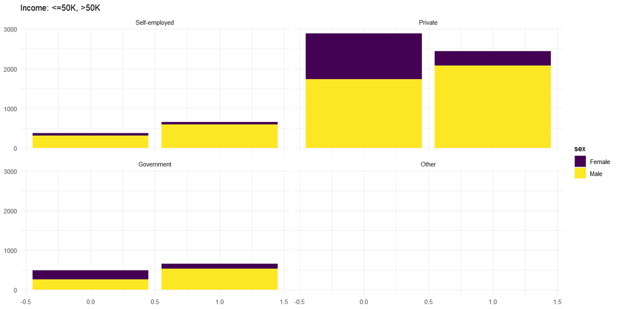

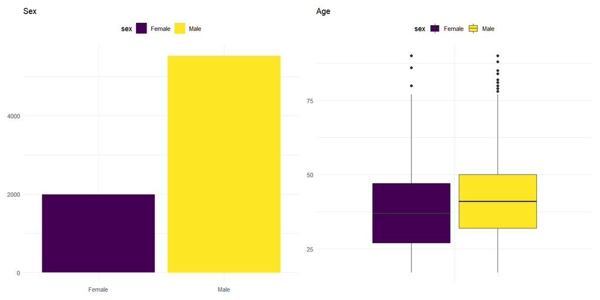

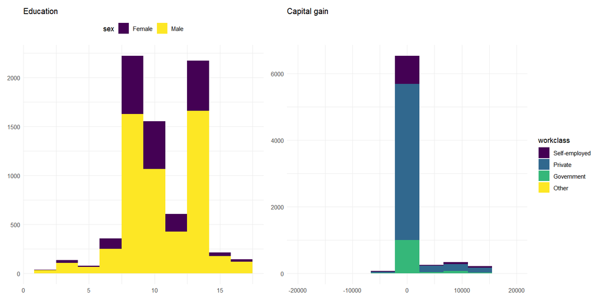

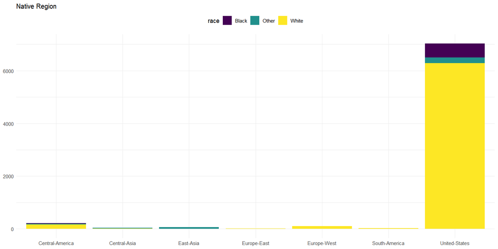

# Logistic regression with “Spike and Slab” prior

In order to model the effects of the predictors on the response, we will implement a **General Linear Model for binary data**, with **logistic link function**. Furthermore, we will use a **“Spike and Slab” Prior** in order to perform model selection, as in the case of GLMs it is not possible to to compute the **posterior model probability**, which implicitly performs predictor selection.

Assume the response variable $Y$ is binary, $Y \in {0,1}$

$$Y_i | \pi_i \sim Bern(\pi_i) \qquad
i=1,...,n$$

$$\pi_i = h(\beta^T x_i)$$
where $h(\cdot)$ is an Inverse-Link function which guarantees that $E(Y|\cdot) \in \{0,1\}$

in the case of logistic regression:

$$logit(\pi_i) = log \bigg( \frac{\pi_i}{1
- \pi_i} \bigg) = \eta = \beta^Tx_i$$
the logistic function is then found as:

$$\frac{\pi_i}{1 - \pi_i} =
\eta$$

$$\pi_i = \frac{\exp(\beta^Tx_i)}{1 +
\exp(\beta^Tx_i)}$$

The likelihood is:

$$p(y | \beta) = \prod_{i=1}^n p(y_i |
\pi_i) = \prod_{i=1}^n \pi^{y_i}(1 - \pi_i)^{1-y_i} = \prod_{i=1}^n
h(\beta^Tx_i)^{y_i} (1-h(\beta^Tx_i))^{1-y_i}$$

While the Prior on $\beta = (\beta_1,...,\beta_p)^T$ is:

$$\begin{aligned} \beta_j &\sim
N(\beta_{0j}, \sigma^2_{0j}) \\ p(\beta) &= \prod_{j=1}^p dN(\beta_j
| \beta_{0j}, \sigma^2_{0j}) \end{aligned}$$

Which is not conjugate to the model. The following posterior distribution should be therefore approximated using a Metropolis Hastings algorithm.

$$p(\beta | y) \propto p(y |
\beta)p(\beta)$$

## “Spike and Slab” Prior

Consider a GLM of the form

$$E(Y|x) = h(\beta_1 X_1 + ... +
\beta_pX_p)$$

we introduce a $(p,1)$ binary vector $\gamma = (\gamma_1,...,\gamma_p)^T$ such that

$$\gamma_j = \begin{cases} 1 &
\mbox{if} \qquad X_j \quad \mbox{is included in the model}\\ 0 &
\mbox{if} \qquad X_j \quad \mbox{is not included in the model}
\end{cases}$$

so that $\gamma_j$ “controls” the inclusion of X_j among the predictors.

We treat $\gamma$ as a parameter and do posterior inference on it

The expectation of $Y|x$ becomes:

$$E(Y|x) = h(\gamma_1\beta_1 X_1 + ... +
\gamma_p\beta_pX_p)$$
So we now need to assign priors both to $\gamma = (\gamma_1,...,\gamma_p)^T$ and $\beta = (\beta_1,...,\beta_p)^T$

that are:

$$\gamma_j \sim Bern(w) \qquad \beta_j
\sim N(\beta_{0j},\sigma^2_{0j})$$

## Metropolis Hastings algorithm

The Metropolis Hastings algorithm is a generalization of Gibbs and Metropolis algorithm, general methods used to approximate functions or distribution $f(x)$. In the case of Bayesian statistics they are widely implemented to approximate posterior distributions.

In this case we need to approximate the vector of parameter $\beta_j = (\beta_\,...,\beta_p)$ starting from initial values $\beta_1^{(1)},...,\beta_p^{(1)}$

Given $S = 5000$ the number of MCMC iterations,

For $s = 1,...,S$  
For $j = 1,...,p$

1. Propose $\beta^*_j \sim q(\beta_j|\beta_j^{(s)})$ from a Normal $dN(\beta_j^*| \beta_j^{(s)},\delta^2_j)$ centered at current value $\beta_j^{(s)}$ (mean) and with fixed $\delta^2_j$ (variance)
2. Compute $r_j = \frac{p(\beta_j^*,\beta_{-j}^{(s)} | y)}{p(\beta_j^s,\beta_{-j}^{(s)} | y)} \frac{q(\beta_j^{(s)} | \beta_j^*)}{q(\beta_j^{(*)} | \beta_j^s)}$ which is the ratio of posteriors, that does not require the computation of $p(y)$, the marginal likelihood, which is not available analytically.
3. Set $\beta_j^{(s+1)} = \begin{cases} \beta_j^* & \mbox{with probability} \quad min\{r_j,1\} \\ \beta_j^{(s)} & \mbox{with probability} \quad 1 - min\{r_j,1\} \end{cases}$

Finally, we obtain the dependent sequence

$\beta = \{\beta^{(1)},...,\beta^{(S)}\}$ with $\beta^{(s)} = \{\beta^{(s)}_1,...,\beta^{(S)}_p\}$

In order to implement it, the first step is expanding factor variables into dummies and adding the Intercept

## Model matrix

## BUGS model

```r
logistic_model = function(){

 # Likelihood

  for(i in 1:n){

    y[i] ~ dbern(pi[i])

    logit(pi[i]) = (gamma * beta) %*% X [i,]

  }

 # Priors

  for(j in 1:p){

    beta[j] ~ dnorm(0, 0.01)

    gamma[j] ~ dbern(w)
  }

  w ~ dbeta(2,1)

}
```

## Approximate Posterior distribution using JAGS

```r
model_posterior = jags(data = model_data,
                      inits = init_values,
                      parameters.to.save = params,
                      model.file = logistic_model,
                      n.iter = 10000,
                      n.chain = 1,
                       n.burnin = 5000,
                      n.thin = 2)
```

## Credible Intervals

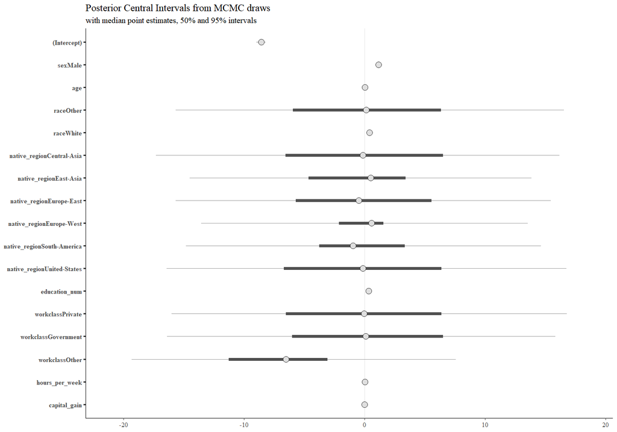

## Posterior coefficients summary

|  | mean | sd | 2.5% | 25% | 50% | 75% | 97.5% |
| --- | --- | --- | --- | --- | --- | --- | --- |
| (Intercept) | -8.5682429 | 0.2456153 | -9.0422649 | -8.7340982 | -8.5668666 | -8.4021005 | -8.1052193 |
| sexMale | 1.1579274 | 0.0696383 | 1.0261705 | 1.1089525 | 1.1561588 | 1.2055330 | 1.2950218 |
| age | 0.0502299 | 0.0024945 | 0.0453677 | 0.0484829 | 0.0502577 | 0.0519398 | 0.0550631 |
| raceOther | 0.2788981 | 9.6650531 | -18.2155758 | -5.9219578 | 0.1477119 | 6.3582392 | 19.5454484 |
| raceWhite | 0.4112639 | 0.0939457 | 0.2252646 | 0.3473889 | 0.4092772 | 0.4746282 | 0.5997191 |
| native_regionCentral-Asia | -0.1240809 | 9.8314427 | -19.8713525 | -6.5464499 | -0.1301633 | 6.5260729 | 18.6746618 |
| native_regionEast-Asia | -0.1952439 | 8.1979469 | -17.6539162 | -4.6298205 | 0.5205581 | 3.4155760 | 16.9446509 |
| native_regionEurope-East | -0.0948240 | 9.2574209 | -18.8815348 | -5.6992554 | -0.4650553 | 5.5583868 | 18.6787099 |
| native_regionEurope-West | 0.1852017 | 7.7300721 | -17.9663045 | -2.1118433 | 0.6015767 | 1.5843760 | 17.3905569 |
| native_regionSouth-America | -0.4905793 | 8.4339412 | -18.1223343 | -3.7592365 | -0.9402074 | 3.3501802 | 17.5321800 |
| native_regionUnited-States | 0.0272526 | 9.9126647 | -19.4125477 | -6.6982197 | -0.1157771 | 6.4079156 | 19.6307184 |
| education_num | 0.3328307 | 0.0129700 | 0.3063715 | 0.3243859 | 0.3328338 | 0.3414995 | 0.3581362 |
| workclassPrivate | 0.0129566 | 9.8546223 | -19.0794473 | -6.5274572 | -0.0101668 | 6.4063029 | 19.7969832 |
| workclassGovernment | 0.1897263 | 9.7222563 | -19.3644072 | -6.0065068 | 0.1042915 | 6.5208449 | 18.6908390 |
| workclassOther | -6.9074719 | 7.7630153 | -22.5009043 | -11.2763679 | -6.5053916 | -3.0814038 | 12.3061235 |
| hours_per_week | 0.0380963 | 0.0028540 | 0.0327653 | 0.0360857 | 0.0380735 | 0.0398944 | 0.0437501 |
| capital_gain | 0.0002095 | 0.0000176 | 0.0001787 | 0.0001995 | 0.0002091 | 0.0002199 | 0.0002417 |
| Deviance | 7580.2019617 | 11.0307536 | 7569.5218400 | 7576.0177338 | 7579.5149140 | 7583.3829435 | 7592.2998518 |

## Posterior probability of inclusion

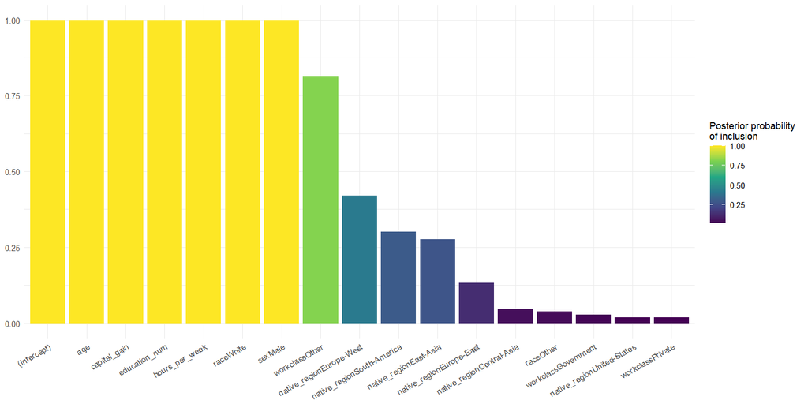

## Model evaluation on test data

```r
S       <- nrow(X.t)
eta     <- matrix(NA, nrow = nrow(beta_post), ncol = S)
pi.star <- matrix(NA, nrow = nrow(beta_post), ncol = S)

for(s in 1:S){

  eta [,s] <- (gamma_post * beta_post) %*% X.t [s,] #Test model matrix

  pi.star [,s] <- exp(eta [,s]) / (1 + exp(eta [,s]))

}

predicted <- colMeans(pi.star)


# We can consider a raster of values for threshold
thresh <- seq(0.2, 0.5, 0.001)
Sensitivity <- numeric(length(thresh))
Specificity <- numeric(length(thresh))

for(j in seq(along=thresh)){
  yhat <- ifelse(predicted >= thresh[j],1,0)
  xx <- table(y.t, yhat)

  Specificity[j] <- xx[1,1] / (xx[1,1]+xx[1,2])
  Sensitivity[j] <- xx[2,2] / (xx[2,1]+xx[2,2])
}

# Youden index
J=which.max(Specificity+Sensitivity-1)

# Set threshold corresponding to Youden Index
predicted <- ifelse(predicted >= thresh[J], 1,0)
```

## ROC curve

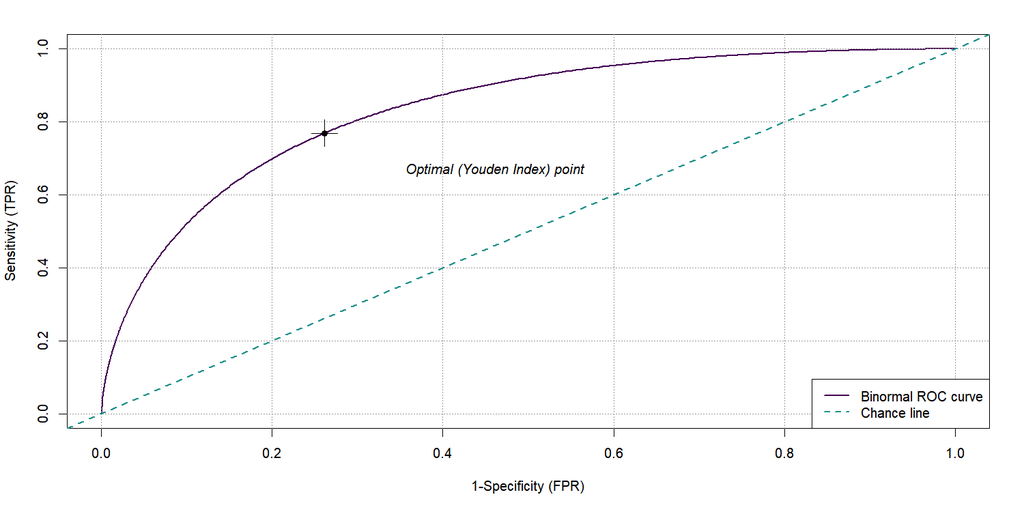

## Confusion matrix

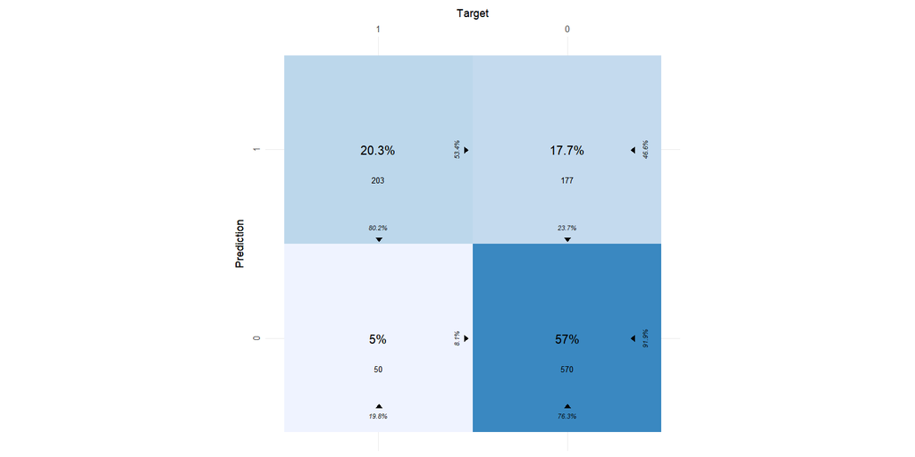

# Multivariate Gaussian copula model

We are now interested in the relationship among some of the most “important” variables in the “Adult Census” dataset. For normally distributed data, it is possible to explain them through a multivariate normal model. In this specific case, as shown by the plot below, the variables of interest are not normally distributed.

We can therefore express these non-normal random variables as functions of unobserved, “latent” normally distributed random variables.

Then we will implement a Multivariate normal model, that is appropriate for all types of ordinal data, both numeric and non-numeric.

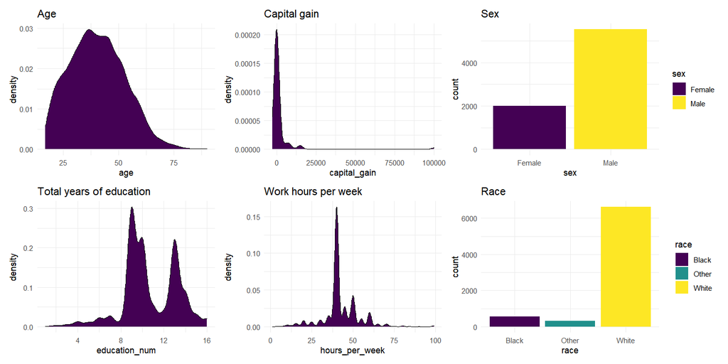

Letting $Y_1,...,Y_n$ be i.i.d. random samples from a p-variate population, our latent normal model is:

$$\begin{aligned}
\textbf{Z}_1,...,\textbf{Z}_n &\sim multivariate \;
normal(\textbf{0}, \Psi) \\ Y_{i,j} &= g_j(Z_{i,j})
\end{aligned}$$

where the $g_1,...,g_p$ functions that relate the value of $Z_i$ to the observed variable $Y_i$. The $g_j$ functions are taken non decreasing so that we can interpret small and large values of $Z_i$ corresponding to small and large values of $Y_i$. The $g_j$ functions can also represent the location of the distribution of $Y_i$, and so we do not need to include an intercept in the model.

$\Psi$ is a correlation matrix, having diagonal entries equal to 1. In this model, the matrix $\Psi$ represents the joint dependencies among the variables and the functions $g1,...,gp$ represent their marginal distributions.

To see how the $g_j$’s represent the margins, let’s calculate the marginal cdf $F_j(y)$

$$\begin{aligned} F_j(y) &= Pr(y_{i,j}
\le y) \\ &= Pr(g_j(Z_{i,j}) \le y) \\ &= Pr(Z_{i,j} \le
g_j^{-1}(y)) \\ &= \Phi(g_j^{-1}(y)) \end{aligned}$$

where $\Phi(z)$ is the cdf of the standard normal distribution. The last line holds because because the diagonal entries of $\Psi$ are all equal to 1, and so the marginal distribution of each $Z_{i,j}$ is a standard normal distribution with cdf $\Phi(z)$.

$F_j(y) = \Phi(g_j^{-1} (y))$ indicates that the marginal distributions of the $Y_j$’s are fully determined by the $g_j$’s and do not depend on the matrix $\Psi$. A model having separate parameters for the univariate marginal distributions, $g_1,...,g_p$, and the multivariate dependencies, $\Psi$, is called a **copula model**, referring to the method of “coupling” a model for multivariate dependence to a model for the marginal distributions of the data.

In this case the dependence is described by a multivariate gaussian distribution, so we have a **multivariate gaussian copula model**.

## Rank likelihood for copula estimation

The unknown parameters in the above written copula model are the matrix $\Psi$ and the non-decreasing functions $g_1,...,g_p$. As we are only interested in $\Psi$, we can use a version of the rank likelihood which quantifies information about $Z_1,...,Z_n$ without having to specify the priors for $g_1,...,g_p$.

Since $g_j$ is non-decreasing:

$$R(\textbf{Y}) = \{ \textbf{Z} : z_{i_1,
j} < z_{i_2, j} \quad if \quad y_{i_1, j} < y_{i_2, j}
\}$$

So the **rank likelihood for the multivariate normal copula model** $Pr(Z \in R(Y) | \Psi)$ does not depend on $g_1,...,g_p$.

As there is no simple conjugate class of prior distributions for our correlation matrix $\Psi$, let’s consider the alternative:

$$\textbf{Z}_1,...,\textbf{Z}_n \sim
multivariate \; normal \; (\textbf{0}, \Sigma)$$

where $\Sigma$ is an arbitrary covariance matrix, not restricted to be a correlation matrix like $\Psi$. In this case a natural prior distribution for $\Sigma$ would be an inverse-Wishart distribution, which would give an inverse-Wishart full conditional distribution and thus make posterior inference available via Gibbs sampling.

Then to each covariance matrix $\Sigma$ there corresponds a unique correlation matrix $\Psi$, obtained by the function:

$$\Psi = h(\Sigma) = \left\{ \sigma_{i,j}
/ \sqrt{\sigma^2_i \sigma^2_j} \right\}$$

## Posterior distribution

$$\begin{aligned} \Sigma &\sim
\mathit{inverse-Wishart}\;(\nu_0,\textbf{S}_0^{-1}) \\
\textbf{Z}_1,...,\textbf{Z}_n &\sim \mathit{multivariate \;
normal}\;(\textbf{0}, \Sigma) \\ Y_{i,j} &= g_j(Z_{i,j})
\end{aligned}$$

### Full conditional distribution of $\Sigma$

the probability density of the $n \times p$ matrix $\textbf{Z}$ is

$$\begin{aligned} p(\textbf{Z}|\Sigma)
&= \prod_{i=1}^{n} (2 \pi )^{- \frac{p}{2} } |\Sigma|^{-
\frac{1}{2}} \exp{ \left\{ -\frac{1}{2} \textbf{z}_i \Sigma^{-1}
\textbf{z}_i \right\} } \\
&= (2 \pi)^{-np/2} |\Sigma|^{-n/2} \exp{ \left\{ - tr(\textbf{Z}^T
\textbf{Z} \Sigma^{-1} )/2 \right\} } \end{aligned}$$

So the full conditional is given by

$$\begin{aligned} p(\Sigma | \textbf{Z},
\textbf{Z} \in R(\textbf{Y})) = p(\Sigma | \textbf{Z}) &\propto
p(\Sigma) \times p(\textbf{Z}| \Sigma) \\
&\propto |\Sigma|^{- (\nu_0 + p +1)/2} \exp{ \left\{
-tr(\textbf{S}_0 \Sigma ^{-1} )/2 \right\}} \times |\Sigma|^{- n/2}
\exp{ \left\{ - tr(\textbf{Z}^T \textbf{Z} \Sigma^{-1} )/2 \right\} } \\
&= |\Sigma|^{- ([\nu_0 + n] + p + 1)/2} \exp{ \left\{ -
tr([\textbf{S}_0 + \textbf{Z}^T \textbf{Z}] \Sigma ^{-1} )/2
\right\}} \end{aligned}$$

which is proportional to an $\mathit{inverse-Wishart} \; (\nu_0 + n, [\textbf{S}_0 + \textbf{Z}^T \textbf{Z}]^{-1})$ density.

### Full conditional distribution of $\textbf{Z}$

$\textbf{Z}$ is a random multivariate normal $(\textbf{0}, \Sigma)$ vector, then the conditional distribution of $Z_j$, given the other elements $\textbf{Z}_{-j} = \textbf{z}_{-j}$, is a univariate normal distribution with mean and variance given by

$$\begin{aligned} \mathbb{E}[Z_j | \Sigma,
\textbf{z}_{-j}] &= \Sigma_{j, -j} (\Sigma_{-j, -j})^{-1}
\textbf{z}_{-j} \\ \mathbb{Var}[Z_j | \Sigma, \textbf{z}_{-j}] &=
\Sigma_{j, j} - \Sigma_{j, -j}(\Sigma_{-j, -j})^{-1} \Sigma_{-j, j}
\end{aligned}$$

conditioning on the information that $\textbf{Z} \in R(\textbf{Y})$, then we know that

$$\max \{ z_{k,j} : y_{k,j} < y_{i,j}
\} < Z_{i,j} < \min \{ z_{k,j} : y_{i,j} < y_{k,j}
\}$$

which implies that the full conditional distribution of $Z_{i,j}$ is a constrained normal distribution.

## Posterior mean and median of correlation coefficients

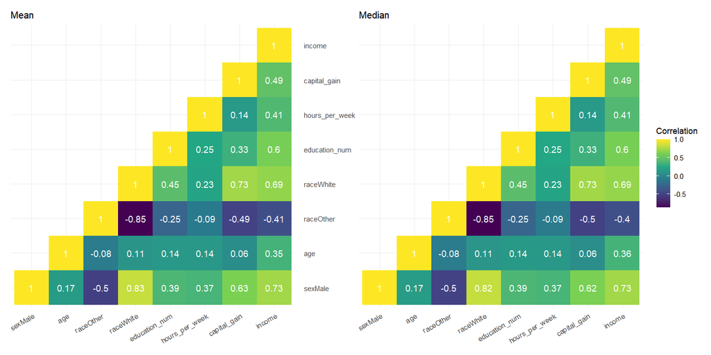

## Posterior quantiles of correlation coefficients

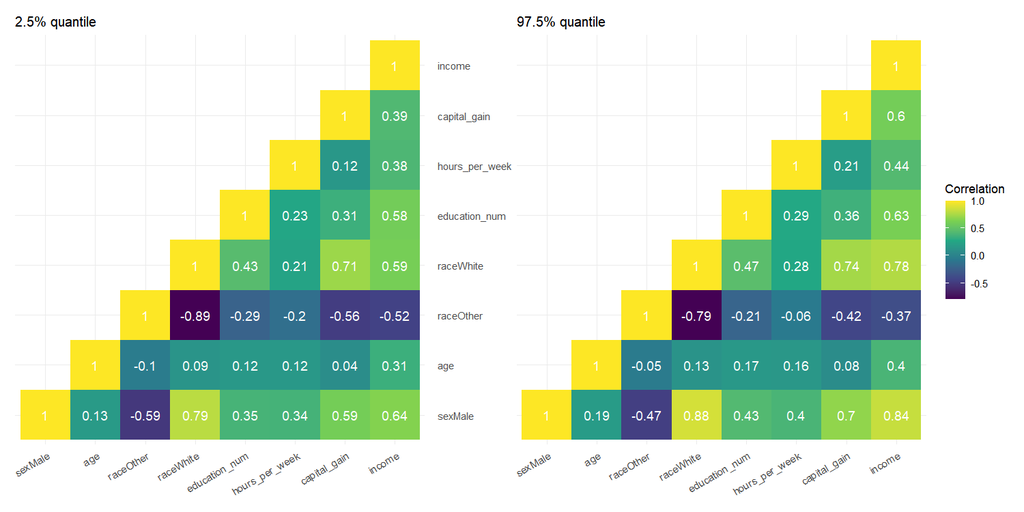

## Regression coefficients

$$\beta_{j|-j} = \Sigma_{j,-j}
(\Sigma_{-j,-j})^{-1}$$
For each variable $j$ is a vector of length $j-1$ that describes how the conditional mean of $Z_j$ depends on the remaining variables $Z_{-j}$

A 95% quantile-based confidence interval is obtained for each $\beta_{j,k}$. If the confidence interval does not contain zero, this means that there is strong evidence of a conditional dependence, with a “+” or a “−” indicating the sign of the posterior median. If the interval does contain zero, there is no conditional dependence between the variables.

95% quantiles for regression coefficients

|  | 2.5% quantile | 50% quantile | 97.5% quantile |
| --- | --- | --- | --- |
| income~sexMale | -0.0848140 | -0.0237115 | 0.4395210 |
| income~age | 0.1798211 | 0.2281183 | 0.2814495 |
| income~raceOther | 0.0870337 | 0.5754051 | 0.6584910 |
| income~raceWhite | 0.3046924 | 1.1478057 | 1.3062305 |
| income~education_num | 0.1822338 | 0.2328112 | 0.2711939 |
| income~hours_per_week | 0.0960683 | 0.1346316 | 0.1706893 |
| income~capital_gain | -0.2196950 | -0.1673033 | -0.0022484 |

# Conclusion

From the **logistic regression** we can conclude that, among the variables object of the analysis, there are many predictors that play an important role in classifying the income of people in less or more than 50K dollars per year. According to the posterior probability of inclusion, the most important, i.e. the variables that are always included in the model, are:

- **Age**
- **Capital_gain**
- **Education_num**
- **hours_per_week**
- **raceWhite**
- **sexMale**

Furthermore, we can say that all of them have a positive effect on the posterior probabilities of being classified in the **Income** class “>50K”. An important result is that the Native region doesn’t seem to have inluence, as all the intervals contain zero and the posterior probability of inclusion is relatively low, according to the data. Also **workclassPrivate** and **workclassGovernment** seem to have small to no impact on the parameter, while **workclassOther** is included in more than 80% of the cases, even though the posterior 95% credible interval contains the zero.

The results obtained from the **Multivariate gaussian copula model** show that there isn’t strong evidence of a conditional dependence between **income** and **sexMale**, given the other variables, despite they have positive correlation. However, there is evidence of conditional dependence between **income** and all the other variables (**age**, **raceOther**, **raceWhite**, **education_num**, **hours_per_week** and **capital_gain**). **income~raceWhite** has a high posterior positive median, which indicates a strong evidence of conditional dependence between the variables.